# Projet d’été : déterminant de l’arrêt lors d’une RI sur Internet

### Exploration de l’usage de l’heuristique : importance des facteurs (spécification par niveau de complexité)

#### Importance des facteurs (régression linéaire)

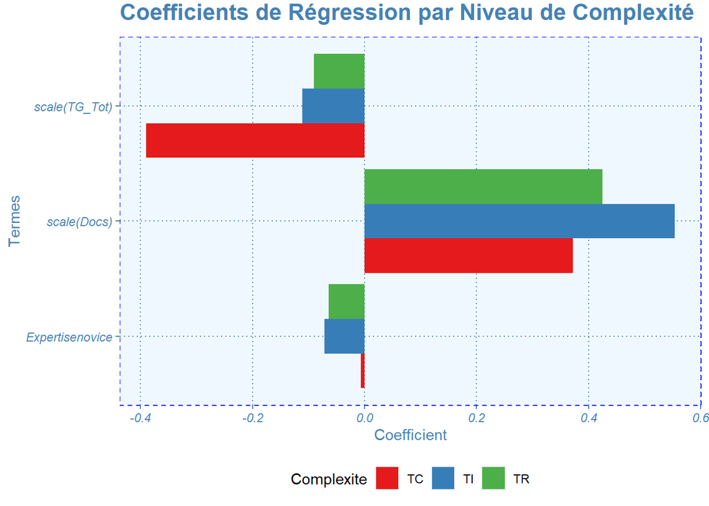

```r
train_data_TC <- train_data %>%
  filter(Complexite == "TC")
train_data_TR <- train_data %>%
  filter(Complexite == "TR")
train_data_TI <- train_data %>%
  filter(Complexite == "TI")

# Régression linéaire
model.reg_TC <- lm(scale(Tps_Tot) ~ scale(TG_Tot) + scale(Docs) + Expertise, train_data_TC)
model.reg_TR <- lm(scale(Tps_Tot) ~ scale(TG_Tot) + scale(Docs)  + Expertise, train_data_TR)
model.reg_TI <- lm(scale(Tps_Tot) ~ scale(TG_Tot) + scale(Docs)  + Expertise, train_data_TI)


library(broom)

# Création des dataframes de coefficients pour chaque modèle
coef_df_TC <- tidy(model.reg_TC) %>% mutate(Complexite = "TC")
coef_df_TC <- coef_df_TC[-1,]
coef_df_TR <- tidy(model.reg_TR) %>% mutate(Complexite = "TR")
coef_df_TR <- coef_df_TR[-1,]
coef_df_TI <- tidy(model.reg_TI) %>% mutate(Complexite = "TI")
coef_df_TI <- coef_df_TI[-1,]

# Fusionner les dataframes de coefficients
all_coef_df <- bind_rows(coef_df_TC, coef_df_TR, coef_df_TI)

# Visualisation des coefficients pour chaque niveau de complexité
ggplot(all_coef_df, aes(x = term, y = estimate, fill = Complexite)) +
  geom_bar(stat = "identity", position = position_dodge()) +
  coord_flip() +
  labs(title = "Coefficients de Régression par Niveau de Complexité",
       x = "Termes",
       y = "Coefficient") +
  blue_theme() +
  scale_fill_brewer(palette = "Set1")
```

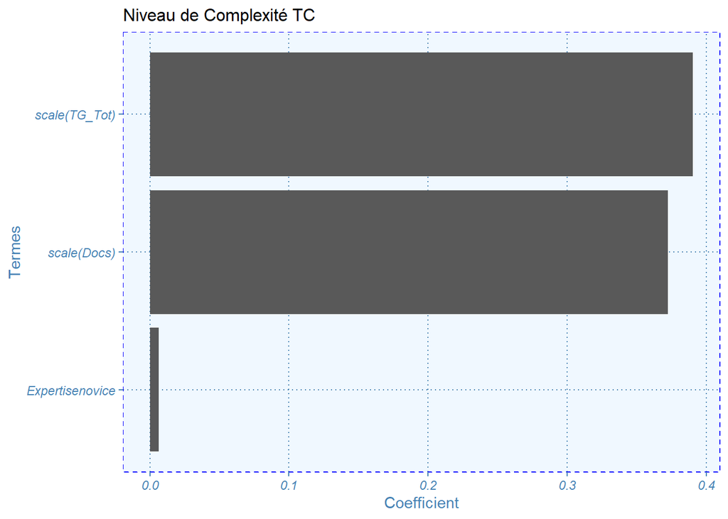

```r
# Visualisation des coefficients pour TC
imp.reg1 <- ggplot(coef_df_TC, aes(x = term, y = abs(estimate))) +
  geom_bar(stat = "identity", position = position_dodge()) +
  coord_flip() +
  labs(subtitle = "Niveau de Complexité TC",
       x = "Termes",
       y = "Coefficient") +
  blue_theme()
imp.reg1
```

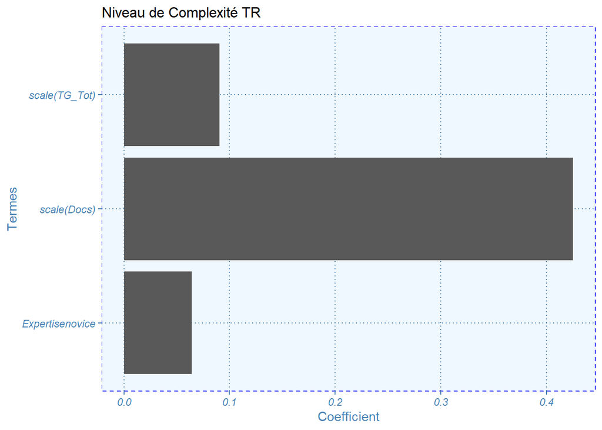

```r
# Visualisation des coefficients pour TR
imp.reg2 <- ggplot(coef_df_TR, aes(x = term, y = abs(estimate))) +
  geom_bar(stat = "identity", position = position_dodge()) +
  coord_flip() +
  labs(subtitle = "Niveau de Complexité TR",
       x = "Termes",
       y = "Coefficient") +
  blue_theme()
imp.reg2
```

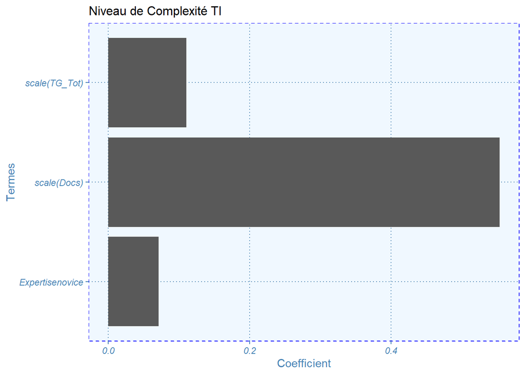

```r
# Visualisation des coefficients pour TI
imp.reg3 <- ggplot(coef_df_TI, aes(x = term, y = abs(estimate))) +
  geom_bar(stat = "identity", position = position_dodge()) +
  coord_flip() +
  labs(subtitle = "Niveau de Complexité TI",
       x = "Termes",
       y = "Coefficient") +
  blue_theme()
imp.reg3
```

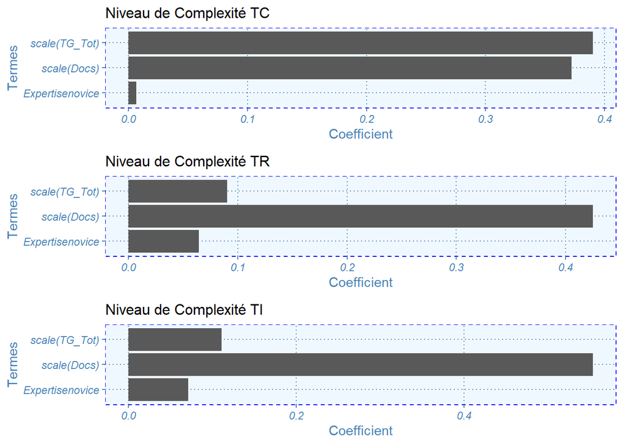

```r
ggarrange(imp.reg1, imp.reg2, imp.reg3, ncol = 1)
```

#### Importance des facteurs (fôrets aléatoires)

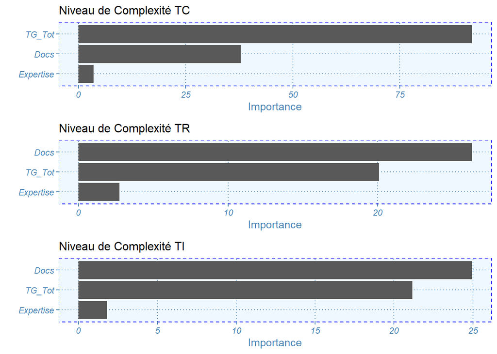

```r
library(ranger)
library(vip)
library(tidymodels)

train_data_TC <- train_data %>%
  filter(Complexite == "TC")
train_data_TR <- train_data %>%
  filter(Complexite == "TR")
train_data_TI <- train_data %>%
  filter(Complexite == "TI")

# Entraînement de la forêt aléatoire TC
rf_fit_TC <- rf_spec %>%
  fit(Tps_Tot ~ TG_Tot + Docs + Expertise, data = train_data_TC)

# Affichage de l'importance des variables TC
imp1 <- vip::vip(rf_fit_TC) +
  labs(subtitle = "Niveau de Complexité TC") +
  blue_theme()

# Entraînement de la forêt aléatoire TR
rf_fit_TR <- rf_spec %>%
  fit(Tps_Tot ~ TG_Tot + Docs + Expertise, data = train_data_TR)

# Affichage de l'importance des variables TR
imp2 <- vip::vip(rf_fit_TR) +
  labs(subtitle = "Niveau de Complexité TR") +
  blue_theme()

# Entraînement de la forêt aléatoire TI
rf_fit_TI <- rf_spec %>%
  fit(Tps_Tot ~ TG_Tot + Docs + Expertise, data = train_data_TI)

# Affichage de l'importance des variables TI
imp3 <- vip::vip(rf_fit_TI) +
  labs(subtitle = "Niveau de Complexité TI") +
  blue_theme()

ggarrange(imp1, imp2, imp3, ncol=1)
```

L’analyse de ces résultats et de ces graphiques montrent que les utilisateurs modifient les caractéristiques de leurs choix, faisant davantage reposer leur arrêt sur une analyse de la soutenabilité de la tâche (i.e. le nombre de documents consultés) pour les tâches les plus complexes (TR et TI), alors que les tâches contrôle (TC) reposent essentiellement sur le taux de gains (information pertinente accumulée). Ce qui confirment notre hypothèse